# CaseStudyProject

C. Banks

June 22, 2016

*For my project, I will present statistics on GDP rankings. The data will come from the World Banks data catalog providing GDP data for 190 ranked countries and for educational data.*

# The Plan consists of steps and related R code

Identify source file, makefile, markdown files and readme file:

### Load the Gross Domestic Product data for the 190 ranked countries in this data set:

### https://d396qusza40orc.cloudfront.net/getdata%2Fdata%2FGDP.csv

### Unzip and Load the educational data from this data set:

### https://d396qusza40orc.cloudfront.net/getdata%2Fdata%2FEDSTATS_Country.csv

## Note: If there are problems with this file download then go to World Bank and try this file:

### http://databank.worldbank.org/data/download/Edstats_csv.zip

### temp <- tempfile()

### download.file(“http://databank.worldbank.org/data/download/Edstats_csv.zip”,temp)

### Educraw <- read.csv(unz(temp, “EdStats_Country.csv”))

### unlink(temp)

Prepare the codebook as follows:

### Set up working directory to ensure all files are contained in case study project directory

### getwd(current working directory)

### setwd(desired working directory)

### setwd(“C:/Users/Celia/Documents/SMU/MSDS6360/Week6/CaseStudy/CaseStudyProject”)

### required install.packages

### downloader

### RCurl

### ggplot2

### repmis

### plyr

### reshape2

### Identify R libraries to load

### Loader

### RCurl

### ggplot2

### repmis

### plyr

### reshape2

Analyze Data - Part 1

### Analysis consists of identifying files for download, tidying raw files,

### Download GDP file directly to working directory from Internet

### download(“https://d396qusza40orc.cloudfront.net/getdata%2Fdata%2FGDP.csv”, destfile=“gdp.csv”)

### download(“https://d396qusza40orc.cloudfront.net/getdata%2Fdata%2FEDSTATS_Country.csv”, destfile=“education.csv”)

### Note: DO THIS IF YOU HAVE PROBLEMS WITH EDUCATIOND DATA SET DOWNLOAD

### Download and unzip Education file to working directory from Internet, load into R

### as raw file

### temp <- tempfile()

### download.file(“http://databank.worldbank.org/data/download/Edstats_csv.zip”,temp)

### educationraw <- read.csv(unz(temp, “EdStats_Country.csv”))

### unlink(temp)

### confirm files downloaded

### list.files()

### Create data frames from downloaded csv files

### gdpraw <- read.csv(“gdp.csv”)

### educationraw <-read.csv(“education.csv”)

### Take a snapshot of file contents and

### see what shape data is in

### head(gdpraw, 15)

### tail(gdpraw)

### str(gdpraw)

### there are NA values in cols x.1, x.5 through x.8 throughout,

### may want to remove the columns. Instructions for case study

### are to remove any NAs, but do a count of them as missing values

### rename field to something meaningful

### change field types from factor to char and numeric

### where needed

### head(educationraw, 15)

### tail(educationraw)

### Look at variable names and types and some preliminary data

### str(educationraw)

### Try to minimize if not eliminate the factor var types

### Re-read files so that character vectors are not changed

### to factors and leave in headers

### gdpraw2 <- read.csv(“gdp.csv”, stringsAsFactors=FALSE, header=FALSE)

### educationraw2 <- read.csv(“education.csv”, stringsAsFactors=FALSE, header=FALSE)

### [Use this if education data is suspect]

### temp <- tempfile()

### download.file(“http://databank.worldbank.org/data/download/Edstats_csv.zip”,temp)

### educationraw2 <- read.csv(unz(temp, “EdStats_Country.csv”), #stringsAsFactors=FALSE, header=FALSE)

### unlink(temp)

Data analysis part 2 – tidy process: Goal of analysis: GDP rankings, by country, income levels, education levels

### any NA values are not relevant to analysis, so

### remove those rows from dataset

### clean02 <- na.omit(clean01)

### look at data to confirm tidy

### str(clean02)

### head(clean02, 20)

### tail(clean02, 10)

Data Analysis – Part 3 Presentation and Interpretation

### sort data on country short name

### clean02[order(clean02$CountryShortName),]

### set IncomeGroup as factor type

### then declare the levels

### clean02$IncomeGroup <- as.factor(clean02$IncomeGroup)

### levels(clean02$IncomeGroup)

### average GDP rankings for “High income: OECD”

### and “High income: nonOECD” groups

### ddply(clean02, ~IncomeGroup, summarize, avgGDP = mean(GDP))

### Plot by Income Group

### qplot(IncomeGroup, data=clean02, geom=“density”, color=factor(IncomeGroup), xlab=“IncomeGroup”, ylab=“GDP-Ranking”)

### and “High income: nonOECD” groups

### aggregate(x = clean02$GDP, by = list(clean02$IncomeGroup), FUN = “quantile”)

### A two-way contingency table Ranking vs. Income Group

### with(clean02, table(cut(GDP, quantile(GDP)), IncomeGroup))

# Answers to Case Study Questions

### Questions

*Match the data based on the country shortcode. How many of the IDs match?* ###Answer: 204

What are the average GDP rankings for the “High income: OECD” and “High income:nonOECD” groups? ###Answer: High income: OECD 1483917.13; High income: nonOECD 104349.83

Plot the GDP for all of the countries. Use ggplot2 to color your plot by Income Group. ###Answer: See the qplot output from code

# References

### Additional info on extracting cols/data from a dataset retrieved on June 20, 2016 from

### http://www.statmethods.net/management/subset.html

### SMU 2016-0509 MSDS 6306 Week 6 Lectures on Case Study Project

### R Help documentation

```r
##Set up working directory to ensure all files are contained
##in case study project directory
##getwd(current working directory)
##getwd()
##setwd(desired working directory)
##setwd("C:/Users/Celia/Documents/SMU/MSDS6360/Week6/CaseStudy/CaseStudyProject")

##required install.packages
##downloader
##RCurl
##ggplot2
##repmis
##plyr
##reshape2
##Identify R libraries to load
##loader
library(downloader)

##RCurl
library(RCurl)
##ggplot2
##install.packages("ggplot2")
library(ggplot2)

##repmis
library(repmis)

##plyr
library(plyr)

##reshape2
library(reshape2)

##analysis consists of identifying files for download, tidying raw files,
##Download GDP file directly to working directory from Internet
download("https://d396qusza40orc.cloudfront.net/getdata%2Fdata%2FGDP.csv", destfile="gdp.csv")
download("https://d396qusza40orc.cloudfront.net/getdata%2Fdata%2FEDSTATS_Country.csv", destfile="education.csv")

##Note: DO THIS IF YOU HAVE PROBLEMS WITH EDUCATIOND DATA SET DOWNLOAD
##Download and unzip Education file to working directory from Internet, load into R
##as raw file
##temp <- tempfile()
##download.file("http://databank.worldbank.org/data/download/Edstats_csv.zip",temp)
##educationraw <- read.csv(unz(temp, "EdStats_Country.csv"))
##unlink(temp)

##confirm files downloaded
list.files()
```

```
## [1] "CaseStudyProject.Rproj"      "CBanks_CaseStudyProject.txt"
## [3] "education.csv"               "gdp.csv"
## [5] "RStudioMakeFile.html"        "RStudioMakeFile.Rmd"
```

```r
##Create data frames from downloaded csv files
gdpraw <- read.csv("gdp.csv")
educationraw <-read.csv("education.csv")

##Take a snapshot of file contents and
##see what shape data is in
head(gdpraw, 15)
```

```
##      X Gross.domestic.product.2012 X.1                X.2          X.3 X.4
## 1                                   NA
## 2                                   NA                    (millions of
## 3                          Ranking  NA            Economy  US dollars)
## 4                                   NA
## 5  USA                           1  NA      United States  16,244,600
## 6  CHN                           2  NA              China   8,227,103
## 7  JPN                           3  NA              Japan   5,959,718
## 8  DEU                           4  NA            Germany   3,428,131
## 9  FRA                           5  NA             France   2,612,878
## 10 GBR                           6  NA     United Kingdom   2,471,784
## 11 BRA                           7  NA             Brazil   2,252,664
## 12 RUS                           8  NA Russian Federation   2,014,775
## 13 ITA                           9  NA              Italy   2,014,670
## 14 IND                          10  NA              India   1,841,710
```

[output cut: 17 more lines]

```r
tail(gdpraw)
```

```
##     X Gross.domestic.product.2012 X.1 X.2 X.3 X.4 X.5 X.6 X.7 X.8
## 325                                NA              NA  NA  NA  NA
## 326                                NA              NA  NA  NA  NA
## 327                                NA              NA  NA  NA  NA
## 328                                NA              NA  NA  NA  NA
## 329                                NA              NA  NA  NA  NA
## 330                                NA              NA  NA  NA  NA
```

```r
str(gdpraw)
```

```
## 'data.frame':    330 obs. of  10 variables:
##  $ X                          : Factor w/ 229 levels "","ABW","ADO",..: 1 1 1 1 215 38 102 51 68 72 ...
##  $ Gross.domestic.product.2012: Factor w/ 195 levels "",".. Not available.  ",..: 1 1 195 1 3 104 115 126 137 148 ...
##  $ X.1                        : logi  NA NA NA NA NA NA ...
##  $ X.2                        : Factor w/ 230 levels "","  East Asia & Pacific",..: 1 1 67 1 219 51 108 83 78 218 ...
##  $ X.3                        : Factor w/ 207 levels ""," 1,008 "," 1,129 ",..: 1 191 207 1 40 178 143 100 66 63 ...
##  $ X.4                        : Factor w/ 7 levels "","a","b","c",..: 1 1 1 1 1 1 1 1 1 1 ...
##  $ X.5                        : logi  NA NA NA NA NA NA ...
##  $ X.6                        : logi  NA NA NA NA NA NA ...
##  $ X.7                        : logi  NA NA NA NA NA NA ...
##  $ X.8                        : logi  NA NA NA NA NA NA ...
```

```r
##there are NA values in cols x.1, x.5 through x.8 throughout,
##may want to remove the columnsâ?¦.instructions for case study
##are to remove any NAs, but do a count of them as missing values
##rename field to something meaningful
##change field types from factor to char and numeric
##where needed
head(educationraw, 15)
```

```
##    CountryCode                    Long.Name         Income.Group
## 1          ABW                        Aruba High income: nonOECD
## 2          ADO      Principality of Andorra High income: nonOECD
## 3          AFG Islamic State of Afghanistan           Low income
## 4          AGO  People's Republic of Angola  Lower middle income
## 5          ALB          Republic of Albania  Upper middle income
## 6          ARE         United Arab Emirates High income: nonOECD
## 7          ARG           Argentine Republic  Upper middle income
## 8          ARM          Republic of Armenia  Lower middle income
## 9          ASM               American Samoa  Upper middle income
## 10         ATG          Antigua and Barbuda  Upper middle income
## 11         AUS    Commonwealth of Australia    High income: OECD
## 12         AUT          Republic of Austria    High income: OECD
## 13         AZE       Republic of Azerbaijan  Upper middle income
## 14         BDI          Republic of Burundi           Low income
```

[output cut: 209 more lines]

```r
tail(educationraw)
```

```
##     CountryCode                        Long.Name        Income.Group
## 229         WSM                            Samoa Lower middle income
## 230         YEM                Republic of Yemen Lower middle income
## 231         ZAF         Republic of South Africa Upper middle income
## 232         ZAR Democratic Republic of the Congo          Low income
## 233         ZMB               Republic of Zambia          Low income
## 234         ZWE             Republic of Zimbabwe          Low income
##                         Region Lending.category Other.groups
## 229        East Asia & Pacific              IDA
## 230 Middle East & North Africa              IDA
## 231         Sub-Saharan Africa             IBRD
## 232         Sub-Saharan Africa              IDA         HIPC
## 233         Sub-Saharan Africa              IDA         HIPC
## 234         Sub-Saharan Africa            Blend
##          Currency.Unit Latest.population.census Latest.household.survey
```

[output cut: 83 more lines]

```r
##Look at variable names and types and some preliminary data
str(educationraw)
```

```
## 'data.frame':    234 obs. of  31 variables:
##  $ CountryCode                                      : Factor w/ 234 levels "ABW","ADO","AFG",..: 1 2 3 4 5 6 7 8 9 10 ...
##  $ Long.Name                                        : Factor w/ 234 levels "American Samoa",..: 5 104 57 99 108 226 4 109 1 2 ...
##  $ Income.Group                                     : Factor w/ 6 levels "","High income: nonOECD",..: 2 2 4 5 6 2 6 5 6 6 ...
##  $ Region                                           : Factor w/ 8 levels "","East Asia & Pacific",..: 4 3 7 8 3 5 4 3 2 4 ...
##  $ Lending.category                                 : Factor w/ 4 levels "","Blend","IBRD",..: 1 1 4 4 3 1 3 2 1 3 ...
##  $ Other.groups                                     : Factor w/ 3 levels "","Euro area",..: 1 1 3 1 1 1 1 1 1 1 ...
##  $ Currency.Unit                                    : Factor w/ 155 levels "","Afghan afghani",..: 8 49 2 5 3 144 6 7 145 44 ...
##  $ Latest.population.census                         : Factor w/ 28 levels "","1970","1979",..: 17 28 3 2 18 22 18 18 17 18 ...
##  $ Latest.household.survey                          : Factor w/ 56 levels "","CPS (monthly)",..: 1 1 39 38 40 1 1 16 1 1 ...
##  $ Special.Notes                                    : Factor w/ 70 levels "","A simple multiplier is used to convert the national currencies of EMU members to euros. The following irrevocable euro conversi"| __truncated__,..: 1 1 27 1 1 1 1 1 1 63 ...
##  $ National.accounts.base.year                      : Factor w/ 44 levels "","1954","1973",..: 25 1 38 28 1 25 22 1 1 18 ...
##  $ National.accounts.reference.year                 : int  NA NA NA NA 1996 NA NA 1996 NA NA ...
##  $ System.of.National.Accounts                      : int  NA NA NA NA 1993 NA 1993 1993 NA NA ...
##  $ SNA.price.valuation                              : Factor w/ 3 levels "","VAB","VAP": 1 1 2 3 2 2 2 2 1 2 ...
```

[output cut: 17 more lines]

```r
##Try to minimize if not eliminate the factor var types
##Re-read files so that character vectors are not changed
##to factors and leave in headers
gdpraw2 <- read.csv("gdp.csv", stringsAsFactors=FALSE, header=FALSE)
educationraw2 <- read.csv("education.csv", stringsAsFactors=FALSE, header=FALSE)

              #[Use this if education data is suspect]
##temp <- tempfile()
##download.file("http://databank.worldbank.org/data/download/Edstats_csv.zip",temp)
##educra2 <- read.csv(unz(temp, "EdStats_Country.csv"),
##stringsAsFactors=FALSE, header=FALSE)
##unlink(temp)

##Goal of analysis:  GDP rankings, by country, income levels, education levels
##o #For educationraw2:
##1)    #$V1 (countrycode), $V3 (income group) - just pull out these two columns from ##educationraw2

##create edufinal extracting only rows for $V1-$V3
edufinal <- subset(educationraw2, select = V1:V3)

##o #For gdpraw2:
##1)    #$V1 (countrycode), $V2([gdp]ranking) â?? line 6 is where data begins and line 236 ##[6:236] #where it ends;
##create gdpfinal from gdpraw without headers and pull in rows 6 to 236
gdpfinal <- gdpraw2[6:236,]

##column $V2 just counts the rows â?? not needed
##column $V3 contains all NAs, remove it
##cols $V7 through $V10 contain all NAs, remove them

##count how many NAs are in dataset
sum(is.na(gdpfinal))
```

```
## [1] 1155
```

```r
##extract columns containing data - $V1, $V4, $V5
gdpfinal2  <- gdpfinal[c(1,4:5)]

##confirm scaled down dataset
str(gdpfinal2)
```

```
## 'data.frame':    231 obs. of  3 variables:
##  $ V1: chr  "USA" "CHN" "JPN" "DEU" ...
##  $ V4: chr  "United States" "China" "Japan" "Germany" ...
##  $ V5: chr  " 16,244,600 " " 8,227,103 " " 5,959,718 " " 3,428,131 " ...
```

```r
##o #For edufinal and gdpfinal2:
##1)    #rename columns to something meaningful
##now create column names in edufinal and gdpfinal2
names(edufinal) <-c("CountryShortName", "CountryLongName", "IncomeGroup")
names(gdpfinal2) <-c("CountryShortName", "CountryLongName", "GDP")

##confirm the var name changes:
str(edufinal)
```

```
## 'data.frame':    235 obs. of  3 variables:
##  $ CountryShortName: chr  "CountryCode" "ABW" "ADO" "AFG" ...
##  $ CountryLongName : chr  "Long Name" "Aruba" "Principality of Andorra" "Islamic State of Afghanistan" ...
##  $ IncomeGroup     : chr  "Income Group" "High income: nonOECD" "High income: nonOECD" "Low income" ...
```

```r
str(gdpfinal2)
```

```
## 'data.frame':    231 obs. of  3 variables:
##  $ CountryShortName: chr  "USA" "CHN" "JPN" "DEU" ...
##  $ CountryLongName : chr  "United States" "China" "Japan" "Germany" ...
##  $ GDP             : chr  " 16,244,600 " " 8,227,103 " " 5,959,718 " " 3,428,131 " ...
```

```r
##2)    #Merge the datasets on CountryShortName
clean01 <- merge(gdpfinal2, edufinal, by="CountryShortName", all=TRUE)

##confirm merge
str(clean01)
```

```
## 'data.frame':    242 obs. of  5 variables:
##  $ CountryShortName : chr  "" "" "" "ABW" ...
##  $ CountryLongName.x: chr  "" "" "" "Aruba" ...
##  $ GDP              : chr  "" "" "" " 2,584 " ...
##  $ CountryLongName.y: chr  NA NA NA "Aruba" ...
##  $ IncomeGroup      : chr  NA NA NA "High income: nonOECD" ...
```

```r
##o #For merged dataset clean01:
##1)    #In GDP column â?? set NAs to 0.001 and convert it to numeric

##check data in GDP to ensure no NAs
##some values are NA â?? need to set to  0.001
clean01$GDP[is.na(clean01$GDP)] <- 0.001

##now remove commas to convert from char to num
clean01$GDP <- as.numeric(gsub('[,]', '', clean01$GDP))
##confirm commas have been removed and var type is numeric
head(clean01)
```

```
##   CountryShortName CountryLongName.x   GDP            CountryLongName.y
## 1                                       NA                         <NA>
## 2                                       NA                         <NA>
## 3                                       NA                         <NA>
## 4              ABW             Aruba  2584                        Aruba
## 5              ADO           Andorra    NA      Principality of Andorra
## 6              AFG       Afghanistan 20497 Islamic State of Afghanistan
##            IncomeGroup
## 1                 <NA>
## 2                 <NA>
## 3                 <NA>
## 4 High income: nonOECD
## 5 High income: nonOECD
## 6           Low income
```

```r
tail(clean01)
```

```
##     CountryShortName CountryLongName.x    GDP
## 237              WSM             Samoa    684
## 238              YEM       Yemen, Rep.  35646
## 239              ZAF      South Africa 384313
## 240              ZAR  Congo, Dem. Rep.  17204
## 241              ZMB            Zambia  20678
## 242              ZWE          Zimbabwe   9802
##                    CountryLongName.y         IncomeGroup
## 237                            Samoa Lower middle income
## 238                Republic of Yemen Lower middle income
## 239         Republic of South Africa Upper middle income
## 240 Democratic Republic of the Congo          Low income
## 241               Republic of Zambia          Low income
## 242             Republic of Zimbabwe          Low income
```

```r
##2)    #Count NAs in dataset before rows with NAs

##count how many IDs match
sum(!is.na(unique(clean01$GDP)))
```

```
## [1] 204
```

```r
##there are 202 IDs that match

##count how many NAs are in dataset
sum(is.na(clean01))
```

```
## [1] 52
```

```r
##there are 34 rows that contain NAs

##any NA values are not relevant to analysis, so
##remove those rows from dataset
clean02 <- na.omit(clean01)

##look at data to confirm tidy
str(clean02)
```

```
## 'data.frame':    203 obs. of  5 variables:
##  $ CountryShortName : chr  "ABW" "AFG" "AGO" "ALB" ...
##  $ CountryLongName.x: chr  "Aruba" "Afghanistan" "Angola" "Albania" ...
##  $ GDP              : num  2584 20497 114147 12648 348595 ...
##  $ CountryLongName.y: chr  "Aruba" "Islamic State of Afghanistan" "People's Republic of Angola" "Republic of Albania" ...
##  $ IncomeGroup      : chr  "High income: nonOECD" "Low income" "Lower middle income" "Upper middle income" ...
##  - attr(*, "na.action")=Class 'omit'  Named int [1:39] 1 2 3 5 12 38 46 50 51 55 ...
##   .. ..- attr(*, "names")= chr [1:39] "1" "2" "3" "5" ...
```

```r
head(clean02, 20)
```

```
##    CountryShortName      CountryLongName.x     GDP
## 4               ABW                  Aruba    2584
## 6               AFG            Afghanistan   20497
## 7               AGO                 Angola  114147
## 8               ALB                Albania   12648
## 9               ARE   United Arab Emirates  348595
## 10              ARG              Argentina  475502
## 11              ARM                Armenia    9951
## 13              ATG    Antigua and Barbuda    1134
## 14              AUS              Australia 1532408
## 15              AUT                Austria  394708
## 16              AZE             Azerbaijan   66605
## 17              BDI                Burundi    2472
## 18              BEL                Belgium  483262
## 19              BEN                  Benin    7557
```

[output cut: 27 more lines]

```r
tail(clean02, 10)
```

```
##     CountryShortName CountryLongName.x      GDP
## 231              VEN     Venezuela, RB   381286
## 233              VNM           Vietnam   155820
## 234              VUT           Vanuatu      787
## 236              WLD             World 72440449
## 237              WSM             Samoa      684
## 238              YEM       Yemen, Rep.    35646
## 239              ZAF      South Africa   384313
## 240              ZAR  Congo, Dem. Rep.    17204
## 241              ZMB            Zambia    20678
## 242              ZWE          Zimbabwe     9802
##                      CountryLongName.y         IncomeGroup
## 231 República Bolivariana de Venezuela Upper middle income
## 233      Socialist Republic of Vietnam Lower middle income
## 234                Republic of Vanuatu Lower middle income
## 236                              World
## 237                              Samoa Lower middle income
## 238                  Republic of Yemen Lower middle income
## 239           Republic of South Africa Upper middle income
## 240   Democratic Republic of the Congo          Low income
## 241                 Republic of Zambia          Low income
## 242               Republic of Zimbabwe          Low income
```

```r
##*> Data Analysis â?? Part 3
##o #Presentation and Interpretation
##sort data on country short name
clean02[order(clean02$CountryShortName),]
```

```
##     CountryShortName              CountryLongName.x      GDP
## 4                ABW                          Aruba     2584
## 6                AFG                    Afghanistan    20497
## 7                AGO                         Angola   114147
## 8                ALB                        Albania    12648
## 9                ARE           United Arab Emirates   348595
## 10               ARG                      Argentina   475502
## 11               ARM                        Armenia     9951
## 13               ATG            Antigua and Barbuda     1134
## 14               AUS                      Australia  1532408
## 15               AUT                        Austria   394708
## 16               AZE                     Azerbaijan    66605
## 17               BDI                        Burundi     2472
## 18               BEL                        Belgium   483262
## 19               BEN                          Benin     7557
```

[output cut: 597 more lines]

```r
##set IncomeGroup as factor type
##then declare the levels
clean02$IncomeGroup <- as.factor(clean02$IncomeGroup)
levels(clean02$IncomeGroup)
```

```
## [1] ""                     "High income: nonOECD" "High income: OECD"
## [4] "Low income"           "Lower middle income"  "Upper middle income"
```

```r
##average GDP rankings for "High income: OECD"
##and "High income: nonOECD" groups
ddply(clean02, ~IncomeGroup, summarize, avgGDP = mean(GDP))
```

```
##            IncomeGroup      avgGDP
## 1                      16057351.79
## 2 High income: nonOECD   104349.83
## 3    High income: OECD  1483917.13
## 4           Low income    14410.78
## 5  Lower middle income   256663.48
## 6  Upper middle income   231847.84
```

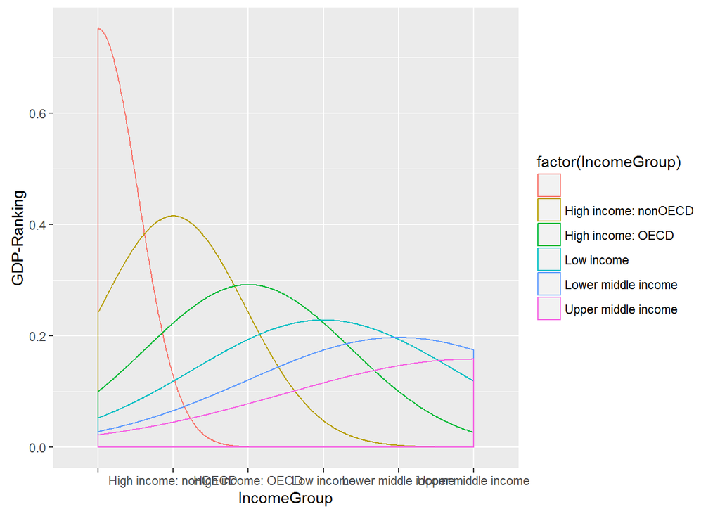

```r
##Plot by Income Group
qplot(IncomeGroup, data=clean02, geom="density", color=factor(IncomeGroup), xlab="IncomeGroup", ylab="GDP-Ranking")
```

```r
##and "High income: nonOECD" groups
aggregate(x = clean02$GDP, by = list(clean02$IncomeGroup), FUN = "quantile")
```

```
##                Group.1        x.0%       x.25%       x.50%       x.75%
## 1                        504431.00  1987485.75  7836856.00 21044104.25
## 2 High income: nonOECD     2584.00    12838.00    28373.00   131204.50
## 3    High income: OECD    13579.00   211146.75   486528.50  1480047.25
## 4           Low income      596.00     3814.00     7843.00    17204.00
## 5  Lower middle income       40.00     2548.75    24272.00    81448.00
## 6  Upper middle income      228.00     9613.00    42945.00   205789.00
##        x.100%
## 1 72440449.00
## 2   711050.00
## 3 16244600.00
## 4   116355.00
## 5  8227103.00
## 6  2252664.00
```

```r
##A two-way contingency table Ranking vs. Income Group
with(clean02, table(cut(GDP, quantile(GDP)), IncomeGroup))
```

```
##                      IncomeGroup
##                          High income: nonOECD High income: OECD Low income
##   (40,7.7e+03]         0                    4                 0         18
##   (7.7e+03,3.75e+04]   0                    9                 1         15
##   (3.75e+04,2.63e+05]  0                    6                11          4
##   (2.63e+05,7.24e+07] 14                    4                18          0
##                      IncomeGroup
##                       Lower middle income Upper middle income
##   (40,7.7e+03]                         17                  11
##   (7.7e+03,3.75e+04]                   16                  10
##   (3.75e+04,2.63e+05]                  16                  13
##   (2.63e+05,7.24e+07]                   4                  11
```

## R Markdown